# 1. Introduction to R

2023-01-17

> [*Back to content page*](https://flatter11.github.io/r.studio/)

Learning objectives

- Use R to perform basic algebraic operations
- Work with variables, vectors and matrices in R
- Produce clear and well-formatted graphs in R
- Install and load R packages for specific needs

Why do we use R in this course?

- Powerful computing, flexible for advanced methods, frequently updated packages, publication-quality graphics
- R resources (or just google “R”)

Other GUI for R

- R studio (highly recommended)
- R-commander

# 1 Use of R as a calculator

- Basic algebraic operations
  - `5+2` `5*2` `5^2` `5/2` `sqrt(16)` `exp(1)` `log(10,base=10)`
- Other algebraic function
  - sin, cos, tan, abs, round, ceiling, floor, etc
- Help
  - help(func), ?func, ??keyword, e.g.`?sin` `??Noraml` ##Type the keyword to find “normal distribution” in the list
- Example – ask R to give an example of the function
  - example(func)

# 2 Vectors, matrices, and their operations

## 2.1 Working with variables

Variable names: acceptable charcters: letter, underscores, dots; case sensitive; cannot start with a number; e.g. age, age.male, max_height, etc…

### 2.1.1 Variable assignment

- RHS is assigned to LHS.
  - `x <- 5` OR `x = 5` #5 is stored inside x.
  - `x = x*3 + 1`

## 2.2 Working with vectors

### 2.2.1 Vector assignment

- c is a combining function
  - `lat = c(2,3,5,1,3,4,2,2)`
  - `out <- c("recovery", "death")` #recovery itself can be a variable, by adding “, R know its a character (Note: cannot add number on character, can only add number to number)
- Sequence generation
  - `seq(1:55)` OR `1:55` #sequence 1 to 55
  - `seq(1,10,by=3)` #skip by 3 (result = 1 4 7 10)
- Replication `rep(x, times)`
  - `rep (5,100)` OR `rep(times=100,x=5)` #replicate 5 by 100 times.
  - `length(rep(times=100,x=5))` #result = 100

### 2.2.2 Vector operations

- `length()` `sum()` `mean()` `median()` `max()` `min()`
- `var()` #varaiance
- `sort(x)` #sorting or ordering vectors
- `which()` #which indices are TRUE
- `summary()` #give u summary abt min, 1st quartile, median, mean, 3rd quatile, max

  ```r
  #set a vector named lat
  lat <- c(2,3,5,1,3,4,2,2)
  sort(lat, decreasing = T) #default sorting is increasing so need to set decreasing as T if we want it to be decreasing
  which(lat==3) #which one is equal to 3?
  ```

  ```
  ## [1] 5 4 3 3 2 2 2 1
  ## [1] 2 5
  ```

- Operations with multiple vectors

  ```r
  #set up 2 vectors
  x = 1:4 #x = 1,2,3,4
  y = c(2,5,3,1)
  # Operations with multiple vectors
  x * y
  x + c(10,100) #try to avoid this (adding 2 character to 4 character) u need to think about how R recycle this
  x+rep(c(10,100)) #safer way to calculate
  ```

  ```
  ## [1]  2 10  9  4
  ## [1]  11 102  13 104
  ## [1]  11 102  13 104
  ```

> Question: How to calculate 1+2+…+1000 using R?

> sum (1:1000) #no need “x=1:1000”

### 2.2.3 Accessing vectors

- `x[n]` #extract the nth value from vector. If result = NA, it’s missing valuae or not applicable
- `x[-n]` #remove the nth value.
  - `lat[c(2,5,7)]` #extract 2nd, 5th and 7th value from lat
  - `lat[-(2:6)]` #remove the 2nd up to 6th value
  - `lat[2]<-NA` #turn 2nd value to missing value
    - `sum(lat,na.rm=T)` #remove the missing value to calculate the sum

    ```r
    lat[2]<-NA
    sum(lat)
    ```

    ```
    ## [1] NA
    ```

    ```r
    sum(lat,na.rm=T)
    ```

    ```
    ## [1] 19
    ```

## 2.3 Working with matrices

- Matrix assignmnet`matrix(data = NA, nrow = 1, ncol = 1, byrow = FALSE, dimnames = NULL)` where
  - `byrow = FALSE` #If FALSE (the default) the matrix is filled by columns, otherwise the matrix is filled by rows.
  - `dimnames` #An empty list is treated as NULL, and a list of length one as row names.

  ```r
  matrix (1:9, nrow=3, ncol=3) #r will build up 1st column then 2nd
  matrix (1:9, nrow=3, ncol=3, byrow = T) #r will build up row first
  matrix(c(1,2,3, 11,12,13), nrow = 2, ncol = 3, byrow = TRUE, dimnames = list(c("row1", "row2"), c("C.1", "C.2", "C.3")))
  ```

  ```
  ##      [,1] [,2] [,3]
  ## [1,]    1    4    7
  ## [2,]    2    5    8
  ## [3,]    3    6    9
  ##      [,1] [,2] [,3]
  ## [1,]    1    2    3
  ## [2,]    4    5    6
  ## [3,]    7    8    9
  ##      C.1 C.2 C.3
  ## row1   1   2   3
  ## row2  11  12  13
  ```

### 2.3.1 Matrix operations

- Addition and multiplication `X+Y`; `X*Y`
- Matrix multiplication `X %*% Y`
- Inverse `solve(Y)`
- Transpose `t(X)`

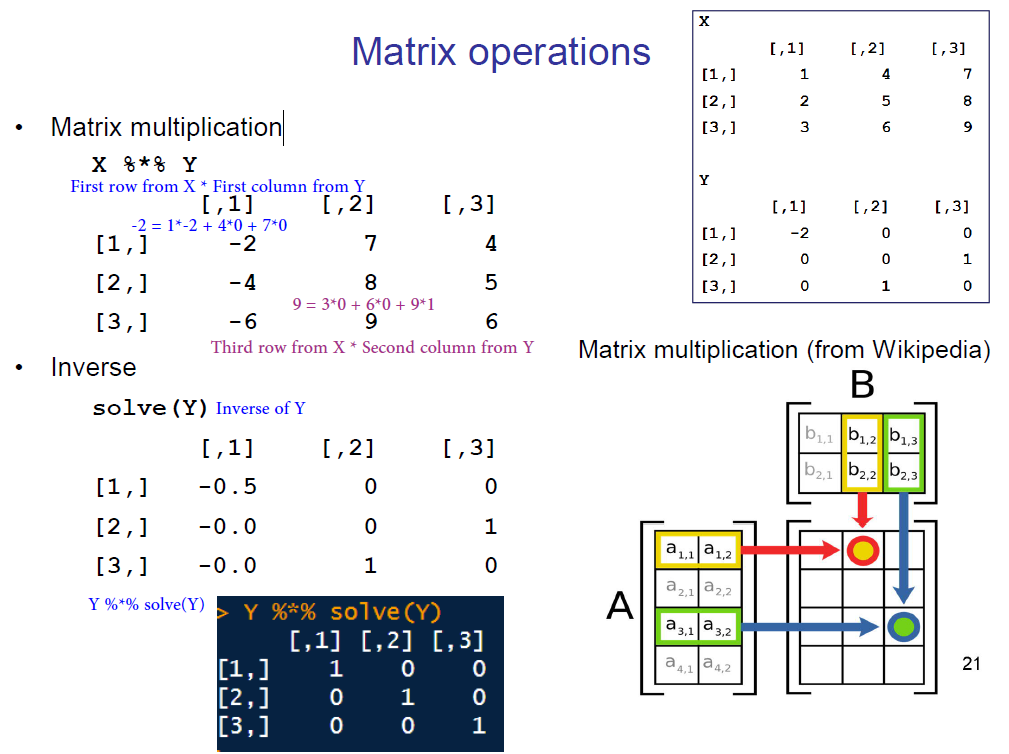

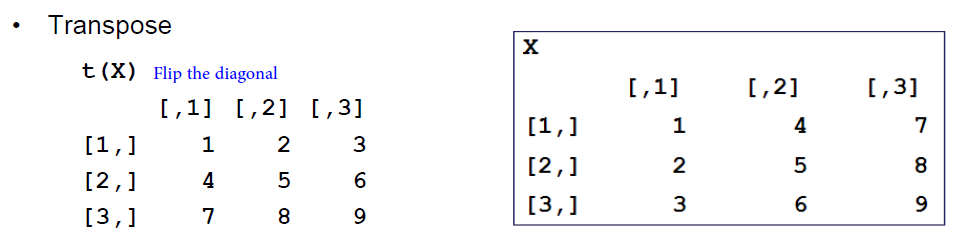

- `colSums()` `rowSums()` `colMeans()` `rowMeans()`
- `Dim ()` #how many rows and columns
- Combining matrices `cbind(X, Y)` #column bind `rbind (X,Y)` #row bind

### 2.3.2 Accessing matrices

- `X [row,column]`

  ```r
  X <- matrix(1:9, nrow=3, ncol=3)
  X [1,2] #extract 1st row and 2nd column
  X [1,2:3] #extract 1st row and 2nd + 3rd column
  ```

  ```
  ## [1] 4
  ## [1] 4 7
  ```

# 3 Logic in R

- Logical operators, `<` `>` `<=` `>=` `==` (equal) `!=`(inequality)
- `!` (negation/not)
- `&` (and)
- `|` (or)

  ```r
  (lat > 2) & (lat != 4) # & = satisfy both statement
  ```

  ```
  ## [1] FALSE    NA  TRUE FALSE  TRUE FALSE FALSE FALSE
  ```

# 4 Data frames

- A general purpose table to store data

  ```r
  #data.frame;combine these varaible to a dataset "data1"
  sex <- c(rep("M",4), rep("F",4))
  age <- c(18, 25, 23, 21, 25, 32, 22, 28)
  height <- c(170, 182, 169, 170, 165, 161, 169, 163)
  data1 <- data.frame(Sex=sex, Age=age, Height=height) #Sex = variable name inside the dataset
  data1
  ```

  ```
  ##   Sex Age Height
  ## 1   M  18    170
  ## 2   M  25    182
  ## 3   M  23    169
  ## 4   M  21    170
  ## 5   F  25    165
  ## 6   F  32    161
  ## 7   F  22    169
  ## 8   F  28    163
  ```

## 4.1 Accessing data frame

- Extract data
  - `data1$Age` #extract one variable
  - `data1[row,colummn]` #treat it as matrix and extract row or column
- Show all the variable names`colnames(data1)`
- Show first or last 6 row of data `head(data.frame)` or `tail(data.frame)`
- Characters are automatically stored as factor in data frames – Not anymore now lmao
  - `data1$Sex <- as.factor(data1$Sex)` #coerce characters to factors/categorical variable
  - `is.factor(data1$Sex)` #result is TRUE coz Sex is a factor
- `attach(data.frame)` to access the variables directly using their names (without “data.frame$”)
  - `detach(data.frame)` to remove these variables
- cbind and rbind can also be used to combine data frames

  ```r
  data1$Smoking <- c("Y", "N", "Y", "N", "N", "N", "N", "N")
  ```

# 5 Summaries, tables

- Object Summaries `summary(data1)`
- Compute Summary Statistics of Data Subsets`aggregate(x, by, FUN)`
  - **x** is an R object, e.g. vector, matrix, data frame
  - **by** is a list of grouping elements
  - **FUN** is a function to be evaluated

  ```r
  aggregate (Height~Sex,data=data1, FUN="mean") #mean height for female and male
  aggregate(data1$Height, by=list(data1$Sex), FUN="mean")
  aggregate(data1[,2:3], by=list(data1$Sex), FUN="mean") #mean age and height for female and male
  ```

  ```
  ##   Sex Height
  ## 1   F 164.50
  ## 2   M 172.75
  ##   Group.1      x
  ## 1       F 164.50
  ## 2       M 172.75
  ##   Group.1   Age Height
  ## 1       F 26.75 164.50
  ## 2       M 21.75 172.75
  ```

- Produce contingency table in **frequencies**

  ```r
  table1 <- table(data1$Sex, data1$Smoking)
  table1
  ```

  ```
  ##
  ##     N Y
  ##   F 4 0
  ##   M 2 2
  ```

- Produce contingency table in **proportions** `prop.table(table, margin)`
  - margin specifies whether row proportions (margin = 1) or column proportions (margin = 2) are calculated

  ```r
  prop.table(table1, margin=2) #calculate column proportions
  ```

  ```
  ##
  ##             N         Y
  ##   F 0.6666667 0.0000000
  ##   M 0.3333333 1.0000000
  ```

# 6 Reading in data

1. read.table(file, header, sep)
   - **file** is the path and filename of the dataset
   - **header**=T indicates column headings are included in the first line of the file
   - **sep** specifies how data are separated (e.g. commas “,”; blank spaces ” “; tabs”)

   ```r
   mvc <- read.table("Folder/mvc.CSV",header=T,sep=",")
   ```

2. read.csv can also be used for .csv (comma separated values) files

   ```r
   mvc <- read.csv("Folder/mvc.csv", header=T)
   ```

   ```r
   ##Read excel files (from google)
   install.packages("readxl")
   library("readxl")
   data <- read_excel("Homework 2.xlsx")
   ```

Note: Description of MVC – the data.frame Dr. Lau gave us

- Data includes ages, heights and maximum voluntary contraction of the quadriceps muscle (MVC) in a group of male alcoholics
- Can MVC be predicted from the other variables / what is the association between them?

## 6.1 Working directory

- Setting the default directory/folder to retrieve or save files
  - `getwd()` #get working directory
  - `setwd()` #set working directory

## 6.2 Packages in R

- Written by different authors for specific purpose
- A lot of packages can be downloaded to the “library” folder from the CRAN website (http://cran.r-project.org)
- Packages can install from remote website in “Packages” → “Install package(s)”
- library(package) or require(package) to load packages

# 7 Useful R materials

- [Paradis E. R for beginners](http://cran.r-project.org/doc/contrib/Paradis-rdebuts_en.pdf)
- [Contributed packages](http://cran.r-project.org/web/packages)
- [Zheng T. Colors in R.](http://www.stat.columbia.edu/~tzheng/files/Rcolor.pdf)